# Project: Investigate a Dataset - [TMDb movie data]

- Introduction
- Data Wrangling
- Exploratory Data Analysis
- Conclusions

## Introduction to the TMDb Movie Dataset

### 1. Dataset Description

> The **TMDb movie dataset** is a rich collection of information about 10,000 movies sourced from The Movie Database (TMDb), which includes essential metadata about each film. The dataset provides valuable insights into movies' commercial success, audience reception, and other key attributes such as cast and genre.

> In addition to basic movie details like title, runtime, and release date, the dataset includes budget and revenue information adjusted for inflation, offering a more accurate comparison of films released across different time periods. User ratings are also available, providing an indication of how audiences responded to each film.

> This dataset is ideal for exploring patterns and trends in the movie industry, such as correlations between budget and revenue, genre preferences over time, and the star power of various actors and actresses.

##### ** Columns in the Dataset and Their Significance

> The dataset includes several columns, each offering different aspects of information about the movies:
> - **id**: Unique identifier for each movie.
> - **imdb_id**: The movie's unique ID on IMDb.
> - **popularity**: A measure of the movie's popularity based on audience interaction on TMDb.
> - **budget**: The production budget of the movie (in the currency of the movie's release year).
> - **revenue**: The total revenue generated by the movie (in the currency of the movie's release year).
> - **original_title**: The original title of the movie as it was released.
> - **cast**: A list of main actors in the movie, separated by pipe (|) characters.
> - **homepage**: The official homepage or website of the movie.
> - **director**: The name of the movie's director.
> - **tagline**: The tagline or promotional phrase used for marketing the movie.
> - **keywords**: Relevant keywords associated with the movie, separated by pipe characters.
> - **overview**: A brief synopsis of the movie's plot.
> - **runtime**: The duration of the movie in minutes.
> - **genres**: A list of genres associated with the movie, separated by pipe characters.
> - **production_companies**: The companies that were involved in the movie's production, separated by pipe characters.
> - **release_date**: The release date of the movie in YYYY-MM-DD format.
> - **vote_count**: The total number of user votes the movie has received.
> - **vote_average**: The average rating the movie has received, based on user votes (out of 10).
> - **release_year**: The year in which the movie was released.
> - **budget_adj**: The inflation-adjusted budget of the movie in 2010 dollars.
> - **revenue_adj**: The inflation-adjusted revenue of the movie in 2010 dollars.

##### ** Significance of the Columns

> - **id** & **imdb_id**: These are essential identifiers that link the data to specific movies, especially for merging or referencing external data sources.
> - **popularity**: Useful for analyzing audience interest and comparing how different movies fare over time.
> - **budget** & **revenue**: Key financial metrics that help evaluate a movie's commercial success. budget_adj & revenue_adj: By adjusting for inflation, these columns enable more accurate comparisons of financial metrics across different years.
> - **cast** & **director**: These columns highlight the key creative forces behind a movie, useful for studying trends around popular actors, actresses, and directors.
> - **genres**: Provides insight into the type of movie, allowing for genre-based analysis such as which genres perform best at the box office.
> - **release_date** & **release_year**: Essential for time-based analysis, such as understanding trends in movie production or seasonal performance.
> - **vote_count** & **vote_average**: Indicates audience engagement and satisfaction, making it possible to investigate correlations between user ratings and other factors like budget or genre.

##### ** Relationships Between Tables

> If the dataset is split into multiple tables (though typically it is a single table for basic datasets like this one), the relationships would typically look like this:
> - **Movies Table**: The primary table containing all the columns listed above, describing each movie.
> - **Cast Table** (if present): A separate table with detailed information about each cast member, where each movie's **id** would serve as a foreign key.
> - **Directors Table** (if present): Could contain information about directors linked to movies by **id**.
> - **Genres Table** (if present): Could be used to normalize the genres, linking each genre to movies via the **id** field.

However, for the dataset you mentioned, it seems to consist of a single table that includes all relevant information, including multiple values in columns like "cast" and "genres."

This TMDb dataset is well-suited for movie trend analysis, prediction tasks, and comparisons across time and genres, making it a valuable resource for data exploration.

### 2. Question(s) for Analysis

> Over the course of the analysis, we plan to explore the following key question:  
> **What factors contribute most significantly to a movie's revenue?**

> To address this primary question, we will analyze the relationship between **revenue** (the dependent variable) and the following independent variables:
> - **Budget**: How does the budget of a movie impact its revenue?
> - **Popularity**: How does movie popularity affect revenue?
> - **Vote Average**: Does a higher user rating (average vote score) correlate with higher revenue?
> - **Genres**: Do certain movie genres tend to generate higher revenues?

By investigating these relationships, we hope to uncover insights into how different aspects of a movie's production and reception influence its financial success.

## Data Wrangling

Here is a step-by-step process to load the data, inspect the DataFrame, and check for missing or errant data. We'll perform multiple operations to examine the data structure and assess its cleanliness.

### Step 1: Load the Data and Inspect the First Few Rows

> We'll start by loading the dataset and printing out the first few lines to get an initial look at the data.

```python
# Load the dataset using pandas
import pandas as pd

file_path = 'Database_TMDb_movie_data/tmdb-movies.csv'  # Replace with the actual path to the dataset
movies_df = pd.read_csv(file_path)
```

```python
# Display the first 3 rows of the dataset
movies_df.head(3)
```

|  | id | imdb_id | popularity | budget | revenue | original_title | cast | homepage | director | tagline | ... | overview | runtime | genres | production_companies | release_date | vote_count | vote_average | release_year | budget_adj | revenue_adj |
| --- | --- | --- | --- | --- | --- | --- | --- | --- | --- | --- | --- | --- | --- | --- | --- | --- | --- | --- | --- | --- | --- |
| 0 | 135397 | tt0369610 | 32.985763 | 150000000 | 1513528810 | Jurassic World | Chris Pratt\|Bryce Dallas Howard\|Irrfan Khan\|Vi... | http://www.jurassicworld.com/ | Colin Trevorrow | The park is open. | ... | Twenty-two years after the events of Jurassic ... | 124 | Action\|Adventure\|Science Fiction\|Thriller | Universal Studios\|Amblin Entertainment\|Legenda... | 6/9/15 | 5562 | 6.5 | 2015 | 1.379999e+08 | 1.392446e+09 |
| 1 | 76341 | tt1392190 | 28.419936 | 150000000 | 378436354 | Mad Max: Fury Road | Tom Hardy\|Charlize Theron\|Hugh Keays-Byrne\|Nic... | http://www.madmaxmovie.com/ | George Miller | What a Lovely Day. | ... | An apocalyptic story set in the furthest reach... | 120 | Action\|Adventure\|Science Fiction\|Thriller | Village Roadshow Pictures\|Kennedy Miller Produ... | 5/13/15 | 6185 | 7.1 | 2015 | 1.379999e+08 | 3.481613e+08 |
| 2 | 262500 | tt2908446 | 13.112507 | 110000000 | 295238201 | Insurgent | Shailene Woodley\|Theo James\|Kate Winslet\|Ansel... | http://www.thedivergentseries.movie/#insurgent | Robert Schwentke | One Choice Can Destroy You | ... | Beatrice Prior must confront her inner demons ... | 119 | Adventure\|Science Fiction\|Thriller | Summit Entertainment\|Mandeville Films\|Red Wago... | 3/18/15 | 2480 | 6.3 | 2015 | 1.012000e+08 | 2.716190e+08 |

3 rows × 21 columns

```python
# Basic information of dataset
movies_df.info()
```

```
<class 'pandas.core.frame.DataFrame'>
RangeIndex: 10866 entries, 0 to 10865
Data columns (total 21 columns):
 #   Column                Non-Null Count  Dtype
---  ------                --------------  -----
 0   id                    10866 non-null  int64
 1   imdb_id               10856 non-null  object
 2   popularity            10866 non-null  float64
 3   budget                10866 non-null  int64
 4   revenue               10866 non-null  int64
 5   original_title        10866 non-null  object
 6   cast                  10790 non-null  object
 7   homepage              2936 non-null   object
 8   director              10822 non-null  object
 9   tagline               8042 non-null   object
 10  keywords              9373 non-null   object
 11  overview              10862 non-null  object
 12  runtime               10866 non-null  int64
 13  genres                10843 non-null  object
 14  production_companies  9836 non-null   object
 15  release_date          10866 non-null  object
 16  vote_count            10866 non-null  int64
 17  vote_average          10866 non-null  float64
 18  release_year          10866 non-null  int64
 19  budget_adj            10866 non-null  float64
 20  revenue_adj           10866 non-null  float64
dtypes: float64(4), int64(6), object(11)
memory usage: 1.7+ MB
```

### Step 2: Check the Size of the DataFrame

> To check the size of the DataFrame (i.e., the number of rows and columns), we use the **.shape** attribute. This will return the dimensions of the DataFrame in the form (rows, columns).

```python
# Check the size of the DataFrame (rows, columns)
movies_df.shape
```

```
(10866, 21)
```

### Step 3: Inspect Data Types and Check for Missing or Errant Data

> Next, we'll inspect the data types of each column to ensure they are appropriate for analysis. This includes checking for missing or possibly errant data. There are several methods you can use:

##### 1. Check Data Types

> This helps us understand if any columns are stored in an incorrect data type (e.g., numeric columns stored as strings).

```python
# Check the data types of each column
movies_df.dtypes
```

```
id                        int64
imdb_id                  object
popularity              float64
budget                    int64
revenue                   int64
original_title           object
cast                     object
homepage                 object
director                 object
tagline                  object
keywords                 object
overview                 object
runtime                   int64
genres                   object
production_companies     object
release_date             object
vote_count                int64
vote_average            float64
release_year              int64
budget_adj              float64
revenue_adj             float64
dtype: object
```

##### 2. Summary Statistics

> This provides an overview of the basic statistics for the numeric columns, such as the mean, standard deviation, min, max, and percentiles.

```python
# Get summary statistics of numerical columns
movies_df.describe()
```

|  | id | popularity | budget | revenue | runtime | vote_count | vote_average | release_year | budget_adj | revenue_adj |
| --- | --- | --- | --- | --- | --- | --- | --- | --- | --- | --- |
| count | 10866.000000 | 10866.000000 | 1.086600e+04 | 1.086600e+04 | 10866.000000 | 10866.000000 | 10866.000000 | 10866.000000 | 1.086600e+04 | 1.086600e+04 |
| mean | 66064.177434 | 0.646441 | 1.462570e+07 | 3.982332e+07 | 102.070863 | 217.389748 | 5.974922 | 2001.322658 | 1.755104e+07 | 5.136436e+07 |
| std | 92130.136561 | 1.000185 | 3.091321e+07 | 1.170035e+08 | 31.381405 | 575.619058 | 0.935142 | 12.812941 | 3.430616e+07 | 1.446325e+08 |
| min | 5.000000 | 0.000065 | 0.000000e+00 | 0.000000e+00 | 0.000000 | 10.000000 | 1.500000 | 1960.000000 | 0.000000e+00 | 0.000000e+00 |
| 25% | 10596.250000 | 0.207583 | 0.000000e+00 | 0.000000e+00 | 90.000000 | 17.000000 | 5.400000 | 1995.000000 | 0.000000e+00 | 0.000000e+00 |
| 50% | 20669.000000 | 0.383856 | 0.000000e+00 | 0.000000e+00 | 99.000000 | 38.000000 | 6.000000 | 2006.000000 | 0.000000e+00 | 0.000000e+00 |
| 75% | 75610.000000 | 0.713817 | 1.500000e+07 | 2.400000e+07 | 111.000000 | 145.750000 | 6.600000 | 2011.000000 | 2.085325e+07 | 3.369710e+07 |
| max | 417859.000000 | 32.985763 | 4.250000e+08 | 2.781506e+09 | 900.000000 | 9767.000000 | 9.200000 | 2015.000000 | 4.250000e+08 | 2.827124e+09 |

##### 3. Check for Missing Values

> This will return the count of missing values in each column, which helps identify columns with incomplete data.

```python
# Check for missing values in the dataset
movies_df.isnull().sum()
```

```
id                         0
imdb_id                   10
popularity                 0
budget                     0
revenue                    0
original_title             0
cast                      76
homepage                7930
director                  44
tagline                 2824
keywords                1493
overview                   4
runtime                    0
genres                    23
production_companies    1030
release_date               0
vote_count                 0
vote_average               0
release_year               0
budget_adj                 0
revenue_adj                0
dtype: int64
```

> We drop columns that are not relevant to the analysis, such as homepage, tagline, keywords, and other unnecessary fields.

```python
# Dropping irrelevant columns
movies_df.drop(['imdb_id', 'homepage', 'tagline', 'keywords', 'overview', 'production_companies'], axis=1, inplace=True)
```

```python
# Confirm that colummns are dropped
movies_df.head()
```

|  | id | popularity | budget | revenue | original_title | cast | director | runtime | genres | release_date | vote_count | vote_average | release_year | budget_adj | revenue_adj |
| --- | --- | --- | --- | --- | --- | --- | --- | --- | --- | --- | --- | --- | --- | --- | --- |
| 0 | 135397 | 32.985763 | 150000000 | 1513528810 | Jurassic World | Chris Pratt\|Bryce Dallas Howard\|Irrfan Khan\|Vi... | Colin Trevorrow | 124 | Action\|Adventure\|Science Fiction\|Thriller | 6/9/15 | 5562 | 6.5 | 2015 | 1.379999e+08 | 1.392446e+09 |
| 1 | 76341 | 28.419936 | 150000000 | 378436354 | Mad Max: Fury Road | Tom Hardy\|Charlize Theron\|Hugh Keays-Byrne\|Nic... | George Miller | 120 | Action\|Adventure\|Science Fiction\|Thriller | 5/13/15 | 6185 | 7.1 | 2015 | 1.379999e+08 | 3.481613e+08 |
| 2 | 262500 | 13.112507 | 110000000 | 295238201 | Insurgent | Shailene Woodley\|Theo James\|Kate Winslet\|Ansel... | Robert Schwentke | 119 | Adventure\|Science Fiction\|Thriller | 3/18/15 | 2480 | 6.3 | 2015 | 1.012000e+08 | 2.716190e+08 |
| 3 | 140607 | 11.173104 | 200000000 | 2068178225 | Star Wars: The Force Awakens | Harrison Ford\|Mark Hamill\|Carrie Fisher\|Adam D... | J.J. Abrams | 136 | Action\|Adventure\|Science Fiction\|Fantasy | 12/15/15 | 5292 | 7.5 | 2015 | 1.839999e+08 | 1.902723e+09 |
| 4 | 168259 | 9.335014 | 190000000 | 1506249360 | Furious 7 | Vin Diesel\|Paul Walker\|Jason Statham\|Michelle ... | James Wan | 137 | Action\|Crime\|Thriller | 4/1/15 | 2947 | 7.3 | 2015 | 1.747999e+08 | 1.385749e+09 |

##### 4. Check for Duplicates

> This checks for duplicate rows, which might need to be dropped if they are not valid.

```python
# Check for duplicate rows
movies_df.duplicated().sum()
```

```
1
```

> Because there is only 1 duplicate row, we remove that row.

```python
# Drop row and set inplace to True to reflect changes in dataset
movies_df.drop_duplicates(inplace=True)
```

##### 5. Check Unique Values in Key Columns

> For categorical columns like **genres**, we can inspect the unique values.  
> This helps identify potential formatting issues, like extra spaces, or errant values in categorical fields.

```python
# Check unique values in the 'genres' column
movies_df['genres'].unique()
```

```
array(['Action|Adventure|Science Fiction|Thriller',
       'Adventure|Science Fiction|Thriller',
       'Action|Adventure|Science Fiction|Fantasy', ...,
       'Adventure|Drama|Action|Family|Foreign',
       'Comedy|Family|Mystery|Romance',
       'Mystery|Science Fiction|Thriller|Drama'], dtype=object)
```

### Data Cleaning

The **budget** and **revenue** columns are essential for our analysis, so we ensure these are converted to numeric types. we also handle missing values by either filling them or dropping rows with missing critical values.

- Clean the dataset by converting necessary columns to numeric, dropping NA values.

```python
# Convert budget and revenue to numeric
movies_df['budget'] = pd.to_numeric(movies_df['budget'], errors='coerce')
movies_df['revenue'] = pd.to_numeric(movies_df['revenue'], errors='coerce')
```

```python
# Handle missing values
movies_df.dropna(subset=['budget', 'revenue'], inplace=True)
```

```python
# Verify that there are no missing values in critical columns
movies_df[['budget', 'revenue']].isnull().sum()
```

```
budget     0
revenue    0
dtype: int64
```

- We add a new column called profit, which is calculated as the difference between a movie's revenue and budget. This is a useful measure for evaluating the financial success of a movie. By analyzing profit, we can better understand which factors lead to profitable films, beyond just revenue. This will be useful for additional insights in the analysis.

```python
# Add a 'profit' column
movies_df['profit'] = movies_df['revenue'] - movies_df['budget']
movies_df['profit']
```

```
0        1363528810
1         228436354
2         185238201
3        1868178225
4        1316249360
            ...
10861             0
10862             0
10863             0
10864             0
10865        -19000
Name: profit, Length: 10865, dtype: int64
```

```python
movies_df.describe()
```

|  | id | popularity | budget | revenue | runtime | vote_count | vote_average | release_year | budget_adj | revenue_adj | profit |
| --- | --- | --- | --- | --- | --- | --- | --- | --- | --- | --- | --- |
| count | 10865.000000 | 10865.000000 | 1.086500e+04 | 1.086500e+04 | 10865.000000 | 10865.000000 | 10865.000000 | 10865.000000 | 1.086500e+04 | 1.086500e+04 | 1.086500e+04 |
| mean | 66066.374413 | 0.646446 | 1.462429e+07 | 3.982690e+07 | 102.071790 | 217.399632 | 5.975012 | 2001.321859 | 1.754989e+07 | 5.136900e+07 | 2.520261e+07 |
| std | 92134.091971 | 1.000231 | 3.091428e+07 | 1.170083e+08 | 31.382701 | 575.644627 | 0.935138 | 12.813260 | 3.430753e+07 | 1.446383e+08 | 9.659103e+07 |
| min | 5.000000 | 0.000065 | 0.000000e+00 | 0.000000e+00 | 0.000000 | 10.000000 | 1.500000 | 1960.000000 | 0.000000e+00 | 0.000000e+00 | -4.139124e+08 |
| 25% | 10596.000000 | 0.207575 | 0.000000e+00 | 0.000000e+00 | 90.000000 | 17.000000 | 5.400000 | 1995.000000 | 0.000000e+00 | 0.000000e+00 | 0.000000e+00 |
| 50% | 20662.000000 | 0.383831 | 0.000000e+00 | 0.000000e+00 | 99.000000 | 38.000000 | 6.000000 | 2006.000000 | 0.000000e+00 | 0.000000e+00 | 0.000000e+00 |
| 75% | 75612.000000 | 0.713857 | 1.500000e+07 | 2.400000e+07 | 111.000000 | 146.000000 | 6.600000 | 2011.000000 | 2.085325e+07 | 3.370173e+07 | 9.092453e+06 |
| max | 417859.000000 | 32.985763 | 4.250000e+08 | 2.781506e+09 | 900.000000 | 9767.000000 | 9.200000 | 2015.000000 | 4.250000e+08 | 2.827124e+09 | 2.544506e+09 |

## Exploratory Data Analysis

We prepare some functions to support exploratory data analysis:

```python
# Import necessary libraries for visualization
import matplotlib.pyplot as plt
import seaborn as sns

# histogram plot
def hist_plot(df, x_col, title, kde_val, x_lb, y_lb):
    plt.figure(figsize=(8, 6))
    sns.histplot(movies_df[x_col], bins=30, kde=kde_val)
    plt.title(title)
    plt.xlabel(x_lb)
    plt.ylabel(y_lb)
    plt.show()
```

```python
# scatter plot
def scatter_plot(df, x_col, y_col, title, x_lb, y_lb):
    plt.figure(figsize=(8, 6))
    sns.scatterplot(data=df, x=x_col, y=y_col)
    plt.title(title)
    plt.xlabel(x_lb)
    plt.ylabel(y_lb)
    plt.show()
```

```python
# Barplot
def bar_plot(x_values, y_index, palette_val, title, x_lb, y_lb):
    plt.figure(figsize=(10, 6))
    sns.barplot(x=x_values, y=y_index, palette=palette_val)
    plt.title(title)
    plt.xlabel(x_lb)
    plt.ylabel(y_lb)
    plt.show()
```

### Question 1: How does the budget of a movie impact its revenue?

We will first look at the distribution of the budget to understand its range and central tendency. This gives us insight into how movie budgets vary across the dataset.

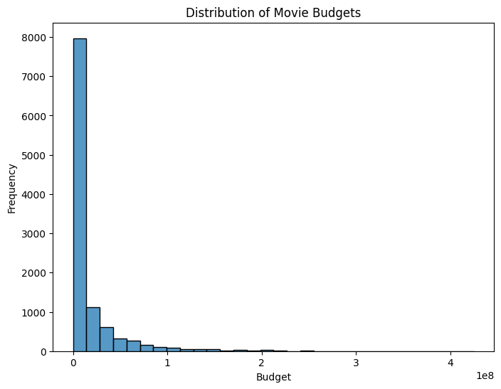

```python
# Plot a histogram to explore the distribution of the movie budget
hist_plot(movies_df, 'budget', 'Distribution of Movie Budgets', False, 'Budget', 'Frequency')
```

Similarly, we will explore the distribution of movie revenues to understand how revenues vary across different movies.

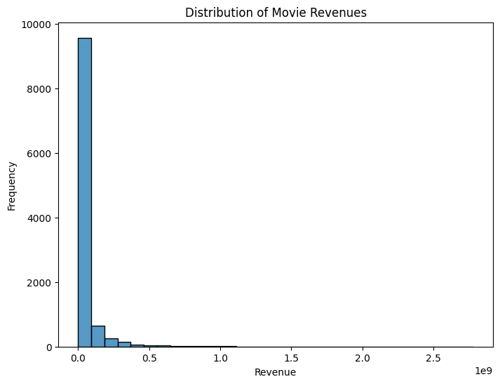

```python
# Plot a histogram to explore the distribution of movie revenue
hist_plot(movies_df, 'revenue', 'Distribution of Movie Revenues', False, 'Revenue', 'Frequency')
```

Now that we've explored both budget and revenue independently, we'll examine their relationship to see if higher budgets correlate with higher revenues.

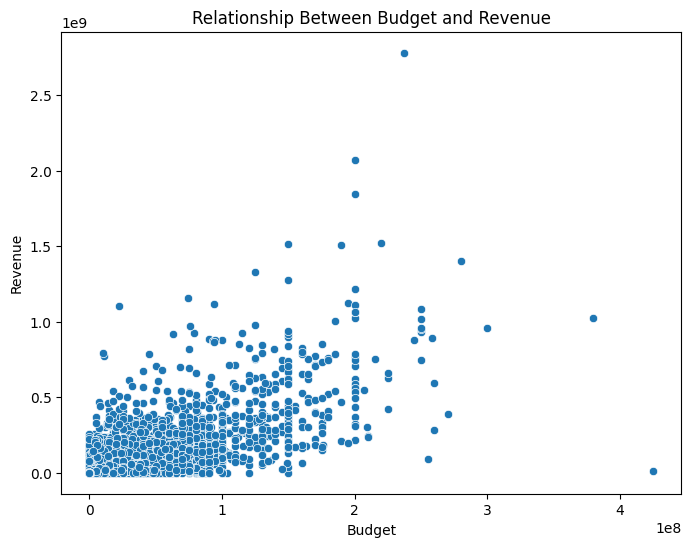

```python
# Scatter plot showing the relationship between budget and revenue
scatter_plot(movies_df, 'budget', 'revenue', 'Relationship Between Budget and Revenue', 'Budget', 'Revenue')
```

In general, higher-budget movies tend to generate more revenue.

We will filter for budgets with USD 100 million and more.

```python
budget = movies_df.query('budget > 0')
blockbuster = budget.query('budget > 1.000000e+08')
blockbuster.describe()
```

|  | id | popularity | budget | revenue | runtime | vote_count | vote_average | release_year | budget_adj | revenue_adj | profit |
| --- | --- | --- | --- | --- | --- | --- | --- | --- | --- | --- | --- |
| count | 282.000000 | 282.000000 | 2.820000e+02 | 2.820000e+02 | 282.000000 | 282.000000 | 282.000000 | 282.000000 | 2.820000e+02 | 2.820000e+02 | 2.820000e+02 |
| mean | 46172.187943 | 3.300546 | 1.544628e+08 | 4.778548e+08 | 123.031915 | 2071.085106 | 6.345035 | 2008.485816 | 1.597181e+08 | 4.910989e+08 | 3.233920e+08 |
| std | 62780.785336 | 3.535419 | 4.436161e+07 | 3.509745e+08 | 33.718360 | 1670.647894 | 0.736825 | 4.961935 | 4.378491e+07 | 3.579313e+08 | 3.362143e+08 |
| min | 22.000000 | 0.157586 | 1.020000e+08 | 0.000000e+00 | 76.000000 | 12.000000 | 4.400000 | 1994.000000 | 9.487238e+07 | 0.000000e+00 | -4.139124e+08 |
| 25% | 2030.000000 | 1.507585 | 1.250000e+08 | 2.453954e+08 | 102.000000 | 838.750000 | 5.800000 | 2005.000000 | 1.298502e+08 | 2.538225e+08 | 1.089377e+08 |
| 50% | 14515.000000 | 2.437016 | 1.500000e+08 | 3.786594e+08 | 121.000000 | 1602.500000 | 6.350000 | 2010.000000 | 1.524601e+08 | 4.058064e+08 | 2.417142e+08 |
| 75% | 68723.250000 | 3.964661 | 1.750000e+08 | 6.303428e+08 | 137.000000 | 2942.250000 | 6.800000 | 2013.000000 | 1.778029e+08 | 6.473074e+08 | 4.886075e+08 |
| max | 417859.000000 | 32.985763 | 4.250000e+08 | 2.781506e+09 | 540.000000 | 9767.000000 | 8.100000 | 2015.000000 | 4.250000e+08 | 2.827124e+09 | 2.544506e+09 |

```python
blockbuster.shape
```

```
(282, 16)
```

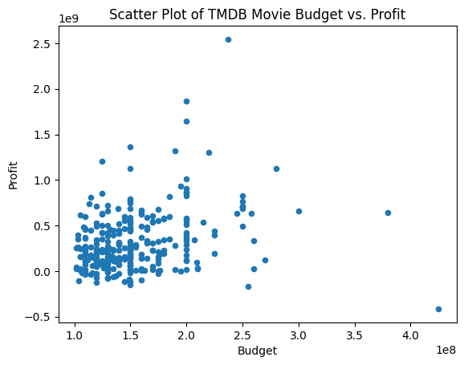

```python
blockbuster.plot(y='profit',x='budget',kind='scatter')
plt.title("Scatter Plot of TMDB Movie Budget vs. Profit")
plt.xlabel("Budget")
plt.ylabel("Profit");
```

We see a lot more outliers when it comes to blockbuster movies with higher budget, but not necessarily having high profit.

To quantify the relationship between budget and revenue, we will compute the Pearson correlation coefficient. A correlation closer to +1 suggests a strong positive relationship between the two variables.

```python
# Calculate the correlation between budget and revenue
correlation = movies_df['budget'].corr(movies_df['revenue'])
print(f"Correlation between Budget and Revenue: {correlation}")
```

```
Correlation between Budget and Revenue: 0.7349279812889292
```

The above correlation coefficient shows that the relationship between budget and revenue is relatively strong.

### Question 2: How does movie popularity affect revenue?

First, we will explore the distribution of the **popularity** variable to understand its range and frequency.

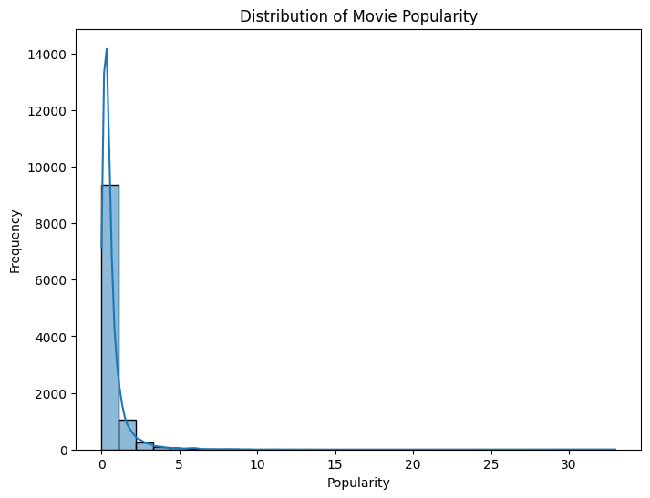

```python
# Plot a histogram for popularity
hist_plot(movies_df, 'popularity', 'Distribution of Movie Popularity', True, 'Popularity', 'Frequency')
```

Next, we will examine the relationship between a movie's popularity and its revenue. A scatter plot will give us a visual understanding of whether more popular movies tend to earn more revenue.

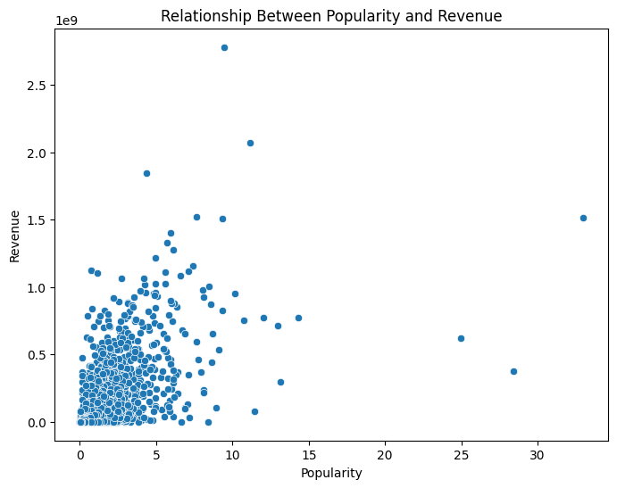

```python
# Scatter plot for popularity vs revenue
scatter_plot(movies_df, 'popularity', 'revenue', 'Relationship Between Popularity and Revenue', 'Popularity', 'Revenue')
```

In general, we see an upward trend, it indicates that movies with higher popularity scores tend to generate more revenue. However, we also be aware of possible outliers that could skew this relationship.

To quantify the relationship between popularity and revenue, we will calculate the Pearson correlation coefficient. This will give us an idea of the strength of the relationship.

```python
# Calculate correlation between popularity and revenue
popularity_revenue_corr = movies_df['popularity'].corr(movies_df['revenue'])
print(f"Correlation between Popularity and Revenue: {popularity_revenue_corr}")
```

```
Correlation between Popularity and Revenue: 0.6633602814125906
```

**Based on the analysis and correlation coefficients above, it may appear that more popular films tend to make more money. However, this relationship may not be as strong as the relationship between budget and revenue, suggesting that other factors are at play.**

### Question 3: Does a higher user rating (average vote score) correlate with higher revenue?

For this research question, we will explore whether movies with higher user ratings (as represented by the average vote score) tend to generate higher revenue. The average vote score represents the average rating given by users on a scale of 0 to 10, and revenue is the total financial earnings of the movie.

We will first explore the distribution of user ratings to understand the spread of average vote scores across the dataset.

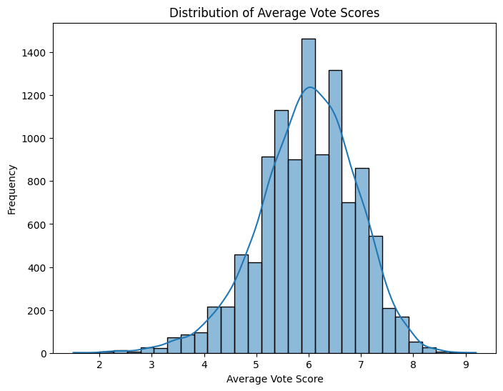

```python
# Plotting the distribution of average vote scores
hist_plot(movies_df, 'vote_average', 'Distribution of Average Vote Scores', True, 'Average Vote Score', 'Frequency')
```

This plot will provide insight into the overall range of user ratings, including whether most movies tend to receive average or high ratings.

Next, we'll explore the relationship between user ratings and revenue using a scatter plot. This visualization will help us assess whether higher-rated movies tend to generate more revenue.

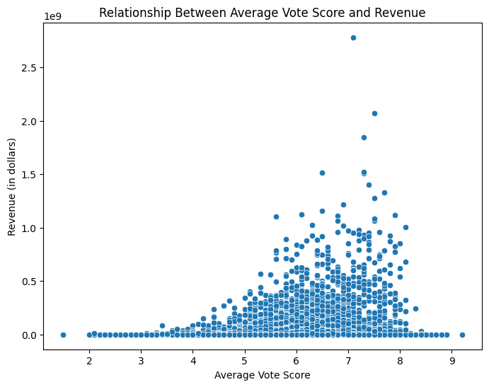

```python
# Scatter plot to explore the relationship between average vote score and revenue
scatter_plot(movies_df, 'vote_average', 'revenue', 'Relationship Between Average Vote Score and Revenue', 'Average Vote Score', 'Revenue (in dollars)')
```

To quantify the relationship between the average vote score and revenue, we will compute the Pearson correlation coefficient.

```python
# Calculate the correlation between vote average and revenue
vote_revenue_corr = movies_df['vote_average'].corr(movies_df['revenue'])
print(f"Correlation between Average Vote Score and Revenue: {vote_revenue_corr}")
```

```
Correlation between Average Vote Score and Revenue: 0.17254138492900245
```

This correlation coefficient is weak and quite far from 1, suggesting the relationship between user ratings and revenue is weak.

We will investigate outliers-movies with high ratings but low revenue, and vice versa.

```python
# Identifying outliers - movies with high average vote score but low revenue, and vice versa
high_rating_low_revenue = movies_df[(movies_df['vote_average'] > 8) & (movies_df['revenue'] < 1e7)]
low_rating_high_revenue = movies_df[(movies_df['vote_average'] < 4) & (movies_df['revenue'] > 1e8)]

print(f"Movies with High Average Vote Score but Low Revenue:\n{high_rating_low_revenue[['original_title', 'vote_average', 'revenue']]}")
print(f"Movies with Low Average Vote Score but High Revenue:\n{low_rating_high_revenue[['original_title', 'vote_average', 'revenue']]}")
```

```
Movies with High Average Vote Score but Low Revenue:
                                         original_title  vote_average  revenue
441         Winter on Fire: Ukraine's Fight for Freedom           8.2        0
538                                The Mask You Live In           8.9        0
550                                      The Fear of 13           8.2        0
609       The Jinx: The Life and Deaths of Robert Durst           8.4        0
611                                   World of Tomorrow           8.2        0
1200                      Black Mirror: White Christmas           8.8        0
1225                          Billy Elliot: The Musical           8.1        0
1322          One Direction: Where We Are - The Concert           8.3        0
1864                            Iron Maiden: Flight 666           8.3        0
2269                                        Life Cycles           8.8        0
2313                                     Tick Tock Tale           8.3        0
2334                     Rush: Beyond the Lighted Stage           8.4        0
2389                           Bill Cunningham New York           8.1  1339650
```

[output cut: 36 more lines]

Some highly rated movies may underperform financially, while some lower-rated movies may generate high revenue, suggesting that user ratings alone do not always dictate box-office success.

**Therefore, user ratings are not the primary driver of financial success.**

### Question 4: Do certain movie genres tend to generate higher revenues?

To explore whether certain movie genres are more likely to generate higher revenues, we will analyze the relationship between the genres of movies and their revenue. Since movies can belong to multiple genres, we will first need to split and analyze the genres for each movie.

First, we will explore the distribution of movie genres in the dataset to understand which genres are most common.

```python
# Splitting the 'genres' column, which contains multiple genres separated by '|'
movies_df['genres'] = movies_df['genres'].fillna('')  # Handling any missing values in the 'genres' column
movies_df['genre_list'] = movies_df['genres'].str.split('|')
```

```python
# Expanding the genre list into individual rows using explode
genre_df = movies_df.explode('genre_list')
```

```python
# Count the occurrences of each genre
genre_count = genre_df['genre_list'].value_counts()
```

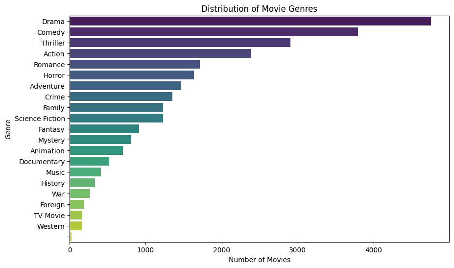

```python
# Plotting the distribution of genres
bar_plot(genre_count.values, genre_count.index, 'viridis', 'Distribution of Movie Genres', 'Number of Movies', 'Genre')
```

From this bar plot, it can be seen that the most popular movie genre is "Drama". In addition, other movie genres such as "Comedy", "Thriller", "Action" are also very popular.

Next, we will analyze the relationship between movie genres and revenue. Since each movie can belong to multiple genres, we will calculate the average revenue for each genre to explore how different genres perform financially.

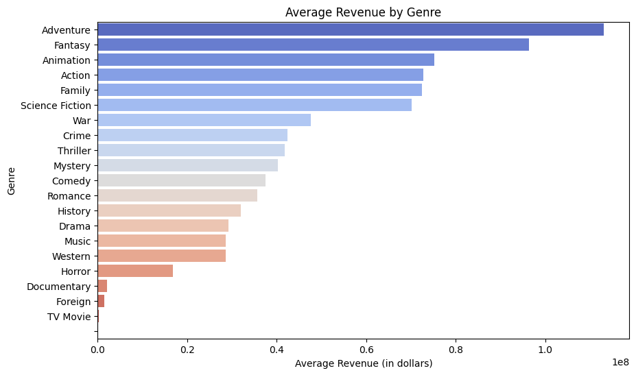

```python
# Grouping the data by genre and calculating the average revenue for each genre
avg_revenue_by_genre = genre_df.groupby('genre_list')['revenue'].mean().sort_values(ascending=False)

# Plotting the average revenue by genre
bar_plot(avg_revenue_by_genre.values, avg_revenue_by_genre.index, 'coolwarm', 'Average Revenue by Genre', 'Average Revenue (in dollars)', 'Genre')
```

From this bar plot, we identify "Adventure", "Fantasy", "Animation", "Action", "Family" and "Science Fiction" are among the genres that tend to generate higher average revenue than other genres.

Since movies can belong to more than one genre, we will look at how multiple genres impact revenue by analyzing revenue across movies that belong to the top-performing genres.

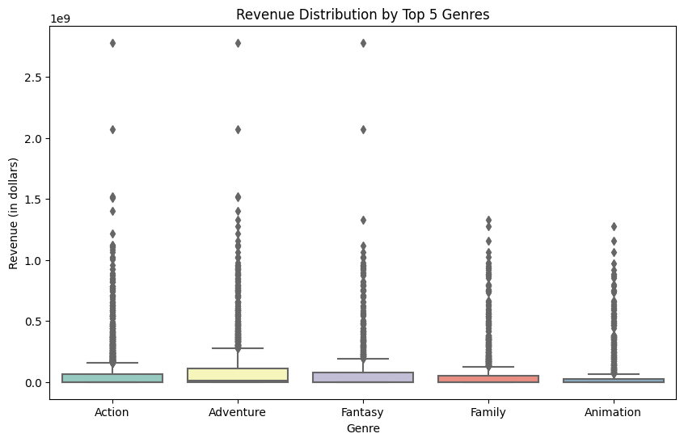

```python
# Filtering out top genres based on average revenue
top_genres = avg_revenue_by_genre.index[:5]

# Filtering the dataset for movies belonging to the top genres
top_genre_df = genre_df[genre_df['genre_list'].isin(top_genres)]

# Plotting boxplots to show revenue distribution for the top 5 genres
plt.figure(figsize=(10, 6))
sns.boxplot(data=top_genre_df, x='genre_list', y='revenue', palette='Set3')
plt.title('Revenue Distribution by Top 5 Genres')
plt.xlabel('Genre')
plt.ylabel('Revenue (in dollars)')
plt.show()
```

To dive deeper, we will analyze the impact of genre combinations on revenue. Certain combinations (like "Action | Adventure" or "Fantasy | Science Fiction") may be more lucrative than single-genre movies.

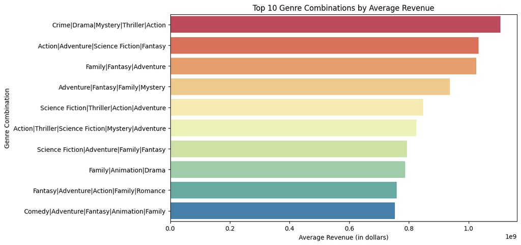

```python
# Grouping by genre combinations and calculating average revenue for each combination
genre_combination_revenue = movies_df.groupby('genres')['revenue'].mean().sort_values(ascending=False).head(10)

# Plotting the top 10 genre combinations by average revenue
bar_plot(genre_combination_revenue.values, genre_combination_revenue.index, 'Spectral', 'Top 10 Genre Combinations by Average Revenue', 'Average Revenue (in dollars)', 'Genre Combination')
```

This plot show us to genre combination tend to generate the highest revenue is "Crime | Drama | Mystery | Thriller | Action". Besides, genre combinations like "Action | Adventure | Science Fiction | Fantasy" and "Family | Fantasy | Adventure" also do well financially.

We will also investigate any outliers—specific genres or genre combinations that generated exceptionally high or low revenue compared to the rest.

```python
# Identifying outliers - genres or genre combinations with high revenue but low frequency
high_revenue_low_frequency = genre_combination_revenue[genre_combination_revenue > 1e8].tail(5)

print(f"High revenue but low frequency genre combinations:\n{high_revenue_low_frequency}")
```

```
High revenue but low frequency genre combinations:
genres
Action|Thriller|Science Fiction|Mystery|Adventure    825500000.0
Science Fiction|Adventure|Family|Fantasy             792910554.0
Family|Animation|Drama                               788241776.0
Fantasy|Adventure|Action|Family|Romance              758410378.0
Comedy|Adventure|Fantasy|Animation|Family            752600867.0
Name: revenue, dtype: float64
```

**In conclusion, certain movie genres, particularly those that appeal to a wide audience tend to generate higher revenues. However, the success of individual movies within these genres can vary, and unique genre combinations can sometimes lead to unexpected financial success.**

### Primary question: What factors contribute most significantly to a movie's revenue?

From the analysis from question 1 to question 4, we see:

- Budget is likely the most significant contributor to a movie's revenue. Movies with larger production budgets often generate higher returns, though diminishing returns may occur at the upper end of the budget scale.
- Popularity also plays a crucial role, as more popular movies (in terms of user activity on TMDb) tend to perform better at the box office.
- Vote average or user ratings may have a weaker but still positive influence on revenue. However, highly rated movies do not always guarantee financial success.
- Genres influence revenue, with certain genres like "Action", "Adventure", and "Fantasy" tending to generate higher revenues compared to niche or less popular genres.

Overall, multiple factors combine to drive a movie's financial success, with budget and popularity being the most significant contributors. However, other variables such as user ratings and genres also play a role in determining how much revenue a movie can generate.

## Conclusions

Let us revisit the questions and summarize our conclusion.

**Question 2:** *How does movie popularity affect revenue?*

> The more popular films tend to make more money. However, this relationship may not be as strong as the relationship between budget and revenue, because other factors are at play.

**Question 4:** *Do certain movie genres tend to generate higher revenues?*

> Certain movie genres, particularly those that appeal to a wide audience tend to generate higher revenues. However, the success of individual movies within these genres can vary, and unique genre combinations can sometimes lead to unexpected financial success.

In conclusion, the factors that combine to drive a movie's financial success is not only budget and popularity but other variables like user ratings and genres also play a role in determining the revenue a movie can generate. This is also answer for primary question *"What factors contribute most significantly to a movie's revenue?"*

## Submitting your Project

```python
# Running this cell will execute a bash command to convert this notebook to an .html file
!python -m nbconvert --to html Investigate_TMDb_Movie_Dataset.ipynb
```

```
[NbConvertApp] Converting notebook Investigate_TMDb_Movie_Dataset.ipynb to html
[NbConvertApp] WARNING | Alternative text is missing on 12 image(s).
[NbConvertApp] Writing 987846 bytes to Investigate_TMDb_Movie_Dataset.html
```